# SMI106 computer lab week 3

Dan Olner

# Working with RMarkdown

## RMarkdown 1: RStudio’s own example / looking at the reference guide

We’ll use **RMarkdown** for preparing assignments. It’s a way to write reports and run code together that can output to Microsoft Word, PDF (or HTML as well for opening in a browser). We’ll use either **Word** or **PDF** output. It’s also a **super-useful tool for making reproducible quantitative social science.**

Let’s look at the RMarkdown example that RStudio provides you with.

1. Open whatever RStudio project you’re working with, if you don’t have it open already.
2. Go to **file / new file / RMarkdown…**
3. Give the file a name (just something like ‘test’) and set the author to your own name, if it isn’t already. Also, choose an output option (choose Word for now, though we can decide later what we want.)

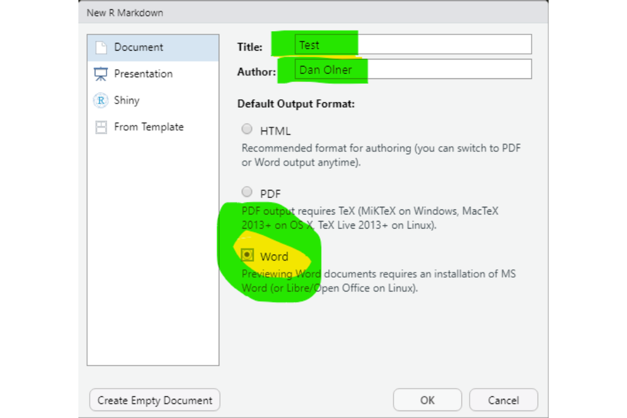

> **Note: the first time you do this, RStudio might prompt you to install some new libraries. Let it install them.**

Select OK, then we should have our new RMarkdown file. **Go to file/save to save it**, or use CTRL + S (or CMD + S on macs).

You should now have an **example RMarkdown file**. These have the **file extension .Rmd** (as compared to just **.R** for normal R scripts.)

Let’s look through what we’ve got there:

- A **header enclosed on each side by three dashes** and **some setup script**. You can leave those alone, though if you want to change names and dates, you can.
- A **document heading** preceded by two hash symbols. (That’s a level 2 heading, more on that shortly.)
- Some text, with some formatting. (The text handily explains more about RMarkdown.)
- A **code chunk** that starts “```{r}”. It has the word ‘cars’ after r, but that’s just a label for the code chunk, you don’t need it.

The important thing to know:

- **The text will output as text, as you’d get in a Word document**
- **The code will run and output what it produces to the document** (unless you ask it not to, more on that in a moment).

So let’s just try **outputting this sample document** and see what happens.

> **Look for the ‘knit’ button at the top of the window. There’s a down symbol on the right of it - click that. You should see the following:**

[figure not shown]

Let’s **select Word first** and see if that works. If you haven’t saved the Rmd script yet, it’ll prompt you to save it now. Then it should **run through the script in the RMarkdown tab** next to the console, before **opening the Word document for you to check over.**

Assuming that worked, let’s also try **outputting as PDF**. Repeat the last step but **choose PDF instead**.

I think Mac installations can automatically output to PDF without any additional steps. Windows users may need to take an extra step (and possibly Mac users too, though my machine was fine.) If PDF isn’t working, we may need to do a couple more installation steps.

If PDF isn’t working yet, type these **into the console** (do **not** include in your R script, you don’t want them running more than once). Note, that’s two colons after `tinytex` in the 2nd line: that just saves us having to load the package with `library(tinytex)`.

```r
install.packages('tinytex')
tinytex::install_tinytex()
```

Once those have run, **try outputting the RMarkdown to PDF again**.

Fingers crossed that worked and you now have a Word and/or PDF document of the sample RMarkdown. You’ll see, the code has run and output to the document.

> To see how to format in RMarkdown, go to **Help / RMarkdown reference guide.** Let’s look through some of what’s on that page. You’ll only need the **first two sections on Markdown syntax and chunk options**. In Markdown syntax:
- Details on **how to format text**
- Including **how to set headings with the hash symbol** (one hash for a top level heading, two hashes for level 2 etc)
- How to make numbered and non-numbered lists
- And a bunch of other formatting options - have a look through them and use what’s useful.
- Note there’s an **inline equation format** too, if you need that.

In the next section, there are some **options for the R code chunks**. You may not need any of these, but it’s worth knowing they’re there. Some of the most important:

- It explains the basic R code chunk: three backticks and the letter r in curly braces opens the code chunk and three more backticks closes it. The back tick on my Mac is **to the left of the Z key** and on Windows machines it’s **below escape**.
- … or you can just **go to code/insert chunk** in the menu. (There’s a shortcut key too though it never works on my Windows machines.)
- As the reference guide shows, **code chunk options go inside the curly braces, like this:**

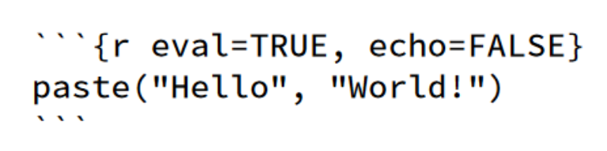

You may never need to use code chunks, but they are sometimes useful. Here’s a couple from the reference worth knowing about:

- `Eval`: if set to false, **the code won’t run but it will display in your document**. That’s useful if you want to show some code off but not have R run it.
- `Echo`: if false, **the code will run, but the code itself won’t be displayed in the document**. You probably don’t want this, as I want to see all the code you’re running in the assignments.

There’s another useful option to avoid having messy outputs. By default, RMarkdown outputs everything from the code. So , for example, imagine if we’d made a vector of random numbers. If we included code to output the vector (the lone `x` here), the chunk would look like this:

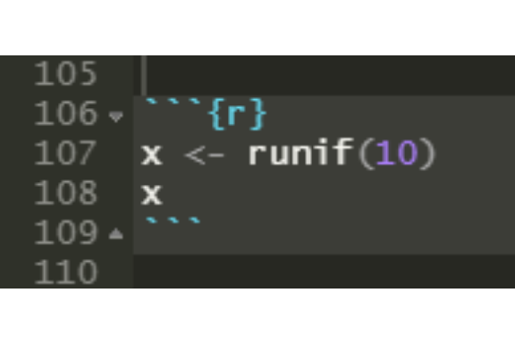

And in the document here, we’d get this:

```r
x <- runif(10)
x
```

```
##  [1] 0.2791008 0.4790933 0.6226169 0.1244202 0.4153056 0.2203117 0.7652387
##  [8] 0.7294971 0.2082110 0.9254166
```

But if that was, say, ten thousand random numbers, we **really** wouldn’t want to output them all. We can tell R to not do the output like this:

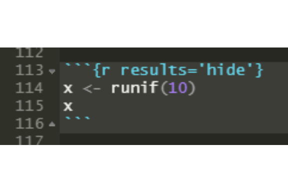

Note: **you can run code within the code chunks just as you would in a normal R script**. And that’s often a useful thing to do when you’re testing code as you make an RMarkdown document. But RStudio’s default behaviour is odd: it’ll **output the result on the script page itself (inline results)**. You may or may not like this - a lot of people hate it - so if you want to stop that happening and have output go to the console as normal, do the following:

- **Go to Tools / Global options**
- **Select the RMarkdown tab**
- **Turn off ‘show output inline for all RMarkdown documents’**

Like this:

[figure not shown]

## RMarkdown 2: editing an RMarkdown document and submitting

There’s an RMarkdown script for the metal bands exercise on this week’s Blackboard. I’ve also emailed you a copy. Now we need to:

- Download and move that file to your RStudio project folder
- Download and move the **metalbands_per_country.csv** file to the **data** subfolder in your project folder.

Once there, open the **metalbands_rmarkdowntest.Rmd** file in RStudio so we can look through it.

Before **next Thursday’s computer lab (21st October)** I want you to have:

- Found the number of metal bands per capita and put that code into RMarkdown code chunks at the end of that document
- Outputted the document to either Word or PDF.
- Checked it looks how you want it to, make any edits if not.
- Submit to me either through Blackboard’s `submit lab assignments’ journal option, or email it to me at d.olner@sheffield.ac.uk

This time **I’ll be checking people submit it**. I want to make sure everyone can use RMarkdown for the assignment.

> **Please ask for help if you get stuck with anything!**

I’ll go over some other things to help with this next.